# Draft for GitHub Tutorial-Lefei Liu project#2 by myself

Title: Analyzing COVID-19 Data with Python: A Data Science Approach

The project embarked on an analytical journey to unravel the trends and implications of COVID-19 vaccination statuses over time among different age groups, aiming to enrich the understanding of the pandemic's progression and the impact of vaccination efforts.-lefei Liu PSU

# Introduction:

The COVID-19 pandemic has had a profound impact on the world. Understanding its spread and effects is crucial for public health. Data analysis plays a vital role in deciphering trends, predicting outbreaks, and formulating strategies. This tutorial demonstrates the use of Python's data science libraries, with a focus on Pandas, to analyze a COVID-19 dataset. This tutorial delves into the analysis of COVID-19 vaccination data using Python. We aim to understand how vaccination status varies over time among different age groups. Such analysis is crucial in the ongoing efforts to combat the pandemic and save lives.

```python
# Import necessary libraries
import pandas as pd
import matplotlib.pyplot as plt
import seaborn as sns

# Load the dataset
data = pd.read_csv('status death.csv')

# Display the first few rows of the dataset
data.head()
```

|  | Entity | Code | Day | unvaccinated | vaccinated_with | vaccinated_without |
| --- | --- | --- | --- | --- | --- | --- |
| 0 | 0.5-4 | NaN | 2022-08-06 | 0.096528 | NaN | 0.0 |
| 1 | 0.5-4 | NaN | 2022-08-13 | 0.019468 | NaN | 0.0 |
| 2 | 0.5-4 | NaN | 2022-08-20 | 0.000000 | NaN | 0.0 |
| 3 | 0.5-4 | NaN | 2022-08-27 | 0.079043 | NaN | 0.0 |
| 4 | 0.5-4 | NaN | 2022-09-03 | 0.039777 | NaN | 0.0 |

# Do a second self-check on your own to make sure no data is missing

```python
# Data Preprocessing and Cleaning

# Checking for missing values
missing_values = data.isnull().sum()

# Converting 'Day' to datetime format for easier handling of temporal data
data['Day'] = pd.to_datetime(data['Day'])

# Replacing NaN values with 0 for 'vaccinated_with' and 'vaccinated_without' columns
# as NaN might indicate no data available or zero status
data['vaccinated_with'] = data['vaccinated_with'].fillna(0)
data['vaccinated_without'] = data['vaccinated_without'].fillna(0)

# Summary of preprocessing steps
preprocessing_summary = {
    "Missing Values Before": missing_values,
    "Missing Values After": data.isnull().sum(),
    "Data Types": data.dtypes
}

preprocessing_summary
```

```
{'Missing Values Before': Entity                  0
 Code                  650
 Day                     0
 unvaccinated            0
 vaccinated_with       418
 vaccinated_without      0
 dtype: int64,
 'Missing Values After': Entity                  0
 Code                  650
 Day                     0
 unvaccinated            0
 vaccinated_with         0
 vaccinated_without      0
 dtype: int64,
 'Data Types': Entity                        object
 Code                         float64
 Day                   datetime64[ns]
 unvaccinated                 float64
 vaccinated_with              float64
 vaccinated_without           float64
 dtype: object}
```

# Answering Framed Questions:

Trend Analysis:

# Explain individual variables in the data

Unvaccinated: Deaths per 100,000 people who have not been vaccinated against COVID-19 vaccinated_with: Deaths per 100,000 people vaccinated one time with COVID-19 vaccine vaccinated_without: Deaths per 100,000 people vaccinated no more 2 times(no include 1 time) with COVID-19 vaccine

# Next, move on to exploratory data analysis and visualization.

This will involve creating visual representations of the data to understand trends, patterns, and distributions.-lefei liu PSU

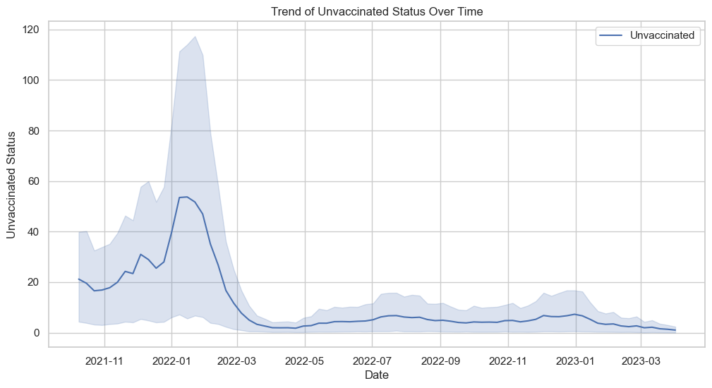

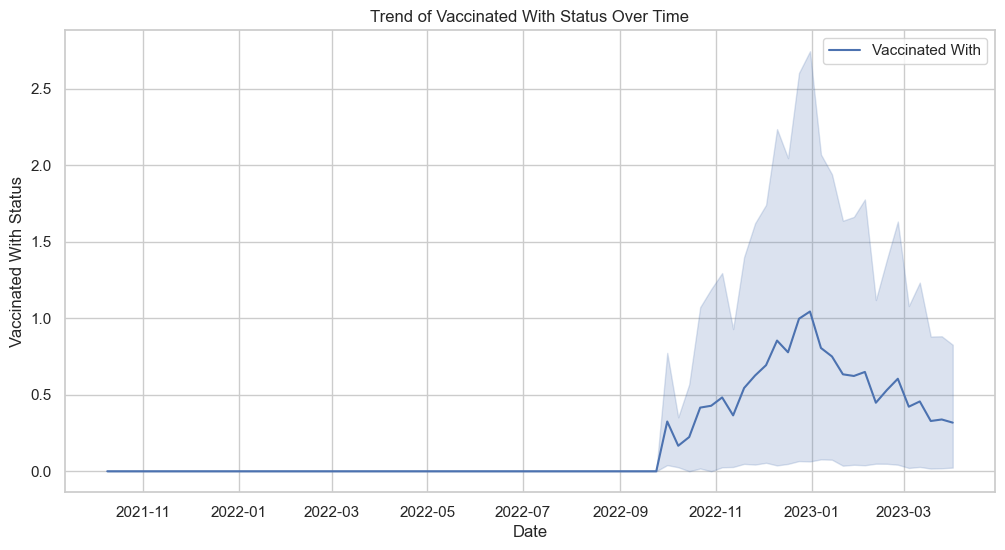

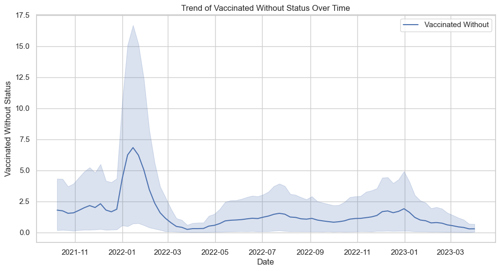

```python
# Setting the style for the plots
sns.set(style="whitegrid")

# Trend Analysis Over Time for Each Status

# Plotting trends for 'unvaccinated'
plt.figure(figsize=(12, 6))
sns.lineplot(x='Day', y='unvaccinated', data=data, label='Unvaccinated')
plt.title('Trend of Unvaccinated Status Over Time')
plt.xlabel('Date')
plt.ylabel('Unvaccinated Status')
plt.legend()
plt.show()

# Plotting trends for 'vaccinated_with'
plt.figure(figsize=(12, 6))
sns.lineplot(x='Day', y='vaccinated_with', data=data, label='Vaccinated With')
plt.title('Trend of Vaccinated With Status Over Time')
plt.xlabel('Date')
plt.ylabel('Vaccinated With Status')
plt.legend()
plt.show()

# Plotting trends for 'vaccinated_without'
plt.figure(figsize=(12, 6))
sns.lineplot(x='Day', y='vaccinated_without', data=data, label='Vaccinated Without')
plt.title('Trend of Vaccinated Without Status Over Time')
plt.xlabel('Date')
plt.ylabel('Vaccinated Without Status')
plt.legend()
plt.show()
```

# View peaks in individual graphs

What can peak data represent?

Answer:

Public Health Policy: Peaks can influence public health policy decisions. If certain policies are followed by a decrease in peaks, they might be considered effective.

```python
import pandas as pd

# Load your data
data = pd.read_csv('status death.csv')

# Convert 'Day' column to datetime
data['Day'] = pd.to_datetime(data['Day'])

# Find the peak (maximum) values for each status
peak_unvaccinated_value = data['unvaccinated'].max()
peak_vaccinated_with_value = data['vaccinated_with'].max()
peak_vaccinated_without_value = data['vaccinated_without'].max()

# Find the corresponding dates for these peak values
peak_unvaccinated_date = data[data['unvaccinated'] == peak_unvaccinated_value]['Day'].dt.strftime('%Y-%m-%d').iloc[0]
peak_vaccinated_with_date = data[data['vaccinated_with'] == peak_vaccinated_with_value]['Day'].dt.strftime('%Y-%m-%d').iloc[0]
peak_vaccinated_without_date = data[data['vaccinated_without'] == peak_vaccinated_without_value]['Day'].dt.strftime('%Y-%m-%d').iloc[0]

# Print the results
print("Peak Unvaccinated Date:", peak_unvaccinated_date)
print("Peak Vaccinated With Date:", peak_vaccinated_with_date)
print("Peak Vaccinated Without Date:", peak_vaccinated_without_date)
```

```
Peak Unvaccinated Date: 2022-01-15
Peak Vaccinated With Date: 2022-12-31
Peak Vaccinated Without Date: 2022-01-15
```

# Conclusion:

Summarize the findings and discuss the importance of vaccination in the context of COVID-19, especially in time dates groups.

The exploratory data analysis phase illustrated trends in various vaccination statuses over time through line plots. This visual exploration is critical for discerning temporal patterns and may help identify spikes in state values that could reflect critical moments during the pandemic.

Peak analysis was designed to determine the maximum date for each vaccination status. These spikes could signal important time markers, such as potential outbreaks or the effectiveness of vaccination campaigns. The identified peak date is part of the results and will be critical for policymakers, health professionals and researchers to strategize further interventions.-Lefei Liu PSU:909592012